# Risk Factor Analysis

## Outcome Variable

**Outcome Variable:** y_rate_len

## Predictor Variables

**Intervention Variable:** hdlvry

**Adjustment Set:**

unadjusted

## Stratifying Variables

The analysis was stratified on these variable(s):

- agecat
- studyid
- country

## Data Summary

| agecat | studyid | country | hdlvry | n_cell | n |
| --- | --- | --- | --- | --- | --- |
| 0-3 months | CMC-V-BCS-2002 | INDIA | 0 | 88 | 88 |
| 0-3 months | CMC-V-BCS-2002 | INDIA | 1 | 0 | 88 |
| 0-3 months | COHORTS | INDIA | 0 | 2863 | 4580 |
| 0-3 months | COHORTS | INDIA | 1 | 1717 | 4580 |
| 0-3 months | EE | PAKISTAN | 0 | 198 | 301 |
| 0-3 months | EE | PAKISTAN | 1 | 103 | 301 |
| 0-3 months | GMS-Nepal | NEPAL | 0 | 113 | 473 |
| 0-3 months | GMS-Nepal | NEPAL | 1 | 360 | 473 |
| 0-3 months | IRC | INDIA | 0 | 370 | 377 |
| 0-3 months | IRC | INDIA | 1 | 7 | 377 |
| 0-3 months | JiVitA-3 | BANGLADESH | 0 | 33 | 313 |
| 0-3 months | JiVitA-3 | BANGLADESH | 1 | 280 | 313 |
| 0-3 months | JiVitA-4 | BANGLADESH | 0 | 369 | 1796 |
| 0-3 months | JiVitA-4 | BANGLADESH | 1 | 1427 | 1796 |
| 0-3 months | NIH-Crypto | BANGLADESH | 0 | 558 | 721 |
| 0-3 months | NIH-Crypto | BANGLADESH | 1 | 163 | 721 |
| 0-3 months | PROVIDE | BANGLADESH | 0 | 478 | 640 |
| 0-3 months | PROVIDE | BANGLADESH | 1 | 162 | 640 |
| 0-3 months | SAS-CompFeed | INDIA | 0 | 140 | 1025 |
| 0-3 months | SAS-CompFeed | INDIA | 1 | 885 | 1025 |
| 3-6 months | CMC-V-BCS-2002 | INDIA | 0 | 298 | 305 |
| 3-6 months | CMC-V-BCS-2002 | INDIA | 1 | 7 | 305 |
| 3-6 months | COHORTS | INDIA | 0 | 2754 | 4481 |
| 3-6 months | COHORTS | INDIA | 1 | 1727 | 4481 |
| 3-6 months | EE | PAKISTAN | 0 | 186 | 278 |
| 3-6 months | EE | PAKISTAN | 1 | 92 | 278 |
| 3-6 months | GMS-Nepal | NEPAL | 0 | 101 | 437 |
| 3-6 months | GMS-Nepal | NEPAL | 1 | 336 | 437 |
| 3-6 months | IRC | INDIA | 0 | 389 | 397 |
| 3-6 months | IRC | INDIA | 1 | 8 | 397 |

[output cut: 122 more lines]

The following strata were considered:

- agecat: 0-3 months, studyid: CMC-V-BCS-2002, country: INDIA
- agecat: 0-3 months, studyid: COHORTS, country: INDIA
- agecat: 0-3 months, studyid: EE, country: PAKISTAN
- agecat: 0-3 months, studyid: GMS-Nepal, country: NEPAL
- agecat: 0-3 months, studyid: IRC, country: INDIA
- agecat: 0-3 months, studyid: JiVitA-3, country: BANGLADESH
- agecat: 0-3 months, studyid: JiVitA-4, country: BANGLADESH
- agecat: 0-3 months, studyid: NIH-Crypto, country: BANGLADESH
- agecat: 0-3 months, studyid: PROVIDE, country: BANGLADESH
- agecat: 0-3 months, studyid: SAS-CompFeed, country: INDIA
- agecat: 12-15 months, studyid: CMC-V-BCS-2002, country: INDIA
- agecat: 12-15 months, studyid: EE, country: PAKISTAN
- agecat: 12-15 months, studyid: GMS-Nepal, country: NEPAL
- agecat: 12-15 months, studyid: IRC, country: INDIA
- agecat: 12-15 months, studyid: JiVitA-4, country: BANGLADESH
- agecat: 12-15 months, studyid: NIH-Crypto, country: BANGLADESH
- agecat: 12-15 months, studyid: PROVIDE, country: BANGLADESH
- agecat: 12-15 months, studyid: SAS-CompFeed, country: INDIA
- agecat: 12-15 months, studyid: SAS-FoodSuppl, country: INDIA
- agecat: 12-15 months, studyid: TanzaniaChild2, country: TANZANIA, UNITED REPUBLIC OF
- agecat: 15-18 months, studyid: CMC-V-BCS-2002, country: INDIA
- agecat: 15-18 months, studyid: EE, country: PAKISTAN
- agecat: 15-18 months, studyid: GMS-Nepal, country: NEPAL
- agecat: 15-18 months, studyid: IRC, country: INDIA
- agecat: 15-18 months, studyid: JiVitA-4, country: BANGLADESH
- agecat: 15-18 months, studyid: NIH-Crypto, country: BANGLADESH
- agecat: 15-18 months, studyid: PROVIDE, country: BANGLADESH
- agecat: 15-18 months, studyid: SAS-CompFeed, country: INDIA
- agecat: 15-18 months, studyid: SAS-FoodSuppl, country: INDIA
- agecat: 15-18 months, studyid: TanzaniaChild2, country: TANZANIA, UNITED REPUBLIC OF
- agecat: 18-21 months, studyid: CMC-V-BCS-2002, country: INDIA
- agecat: 18-21 months, studyid: EE, country: PAKISTAN
- agecat: 18-21 months, studyid: GMS-Nepal, country: NEPAL
- agecat: 18-21 months, studyid: IRC, country: INDIA
- agecat: 18-21 months, studyid: NIH-Crypto, country: BANGLADESH
- agecat: 18-21 months, studyid: PROVIDE, country: BANGLADESH
- agecat: 18-21 months, studyid: TanzaniaChild2, country: TANZANIA, UNITED REPUBLIC OF
- agecat: 21-24 months, studyid: CMC-V-BCS-2002, country: INDIA
- agecat: 21-24 months, studyid: EE, country: PAKISTAN
- agecat: 21-24 months, studyid: GMS-Nepal, country: NEPAL
- agecat: 21-24 months, studyid: IRC, country: INDIA
- agecat: 21-24 months, studyid: NIH-Crypto, country: BANGLADESH
- agecat: 21-24 months, studyid: PROVIDE, country: BANGLADESH
- agecat: 3-6 months, studyid: CMC-V-BCS-2002, country: INDIA
- agecat: 3-6 months, studyid: COHORTS, country: INDIA
- agecat: 3-6 months, studyid: EE, country: PAKISTAN
- agecat: 3-6 months, studyid: GMS-Nepal, country: NEPAL
- agecat: 3-6 months, studyid: IRC, country: INDIA
- agecat: 3-6 months, studyid: JiVitA-3, country: BANGLADESH
- agecat: 3-6 months, studyid: JiVitA-4, country: BANGLADESH
- agecat: 3-6 months, studyid: NIH-Crypto, country: BANGLADESH
- agecat: 3-6 months, studyid: PROVIDE, country: BANGLADESH
- agecat: 3-6 months, studyid: SAS-CompFeed, country: INDIA
- agecat: 3-6 months, studyid: TanzaniaChild2, country: TANZANIA, UNITED REPUBLIC OF
- agecat: 6-9 months, studyid: CMC-V-BCS-2002, country: INDIA
- agecat: 6-9 months, studyid: COHORTS, country: INDIA
- agecat: 6-9 months, studyid: EE, country: PAKISTAN
- agecat: 6-9 months, studyid: GMS-Nepal, country: NEPAL
- agecat: 6-9 months, studyid: IRC, country: INDIA
- agecat: 6-9 months, studyid: JiVitA-4, country: BANGLADESH
- agecat: 6-9 months, studyid: NIH-Crypto, country: BANGLADESH
- agecat: 6-9 months, studyid: PROVIDE, country: BANGLADESH
- agecat: 6-9 months, studyid: SAS-CompFeed, country: INDIA
- agecat: 6-9 months, studyid: SAS-FoodSuppl, country: INDIA
- agecat: 6-9 months, studyid: TanzaniaChild2, country: TANZANIA, UNITED REPUBLIC OF
- agecat: 9-12 months, studyid: CMC-V-BCS-2002, country: INDIA
- agecat: 9-12 months, studyid: COHORTS, country: INDIA
- agecat: 9-12 months, studyid: EE, country: PAKISTAN
- agecat: 9-12 months, studyid: GMS-Nepal, country: NEPAL
- agecat: 9-12 months, studyid: IRC, country: INDIA
- agecat: 9-12 months, studyid: JiVitA-4, country: BANGLADESH
- agecat: 9-12 months, studyid: NIH-Crypto, country: BANGLADESH
- agecat: 9-12 months, studyid: PROVIDE, country: BANGLADESH
- agecat: 9-12 months, studyid: SAS-CompFeed, country: INDIA
- agecat: 9-12 months, studyid: SAS-FoodSuppl, country: INDIA
- agecat: 9-12 months, studyid: TanzaniaChild2, country: TANZANIA, UNITED REPUBLIC OF

### Dropped Strata

Some strata were dropped due to rare outcomes:

- agecat: 0-3 months, studyid: CMC-V-BCS-2002, country: INDIA
- agecat: 18-21 months, studyid: TanzaniaChild2, country: TANZANIA, UNITED REPUBLIC OF

## Methods Detail

We’re interested in the causal parameters $E[Y_a]$ for all values of $a \in \mathcal{A}$. These parameters represent the mean outcome if, possibly contrary to fact, we intervened to set all units to have $A=a$. Under the randomization and positivity assumptions, these are identified by the statistical parameters $\psi_a=E_W[E_{Y|A,W}(Y|A=a,W)]$. In addition, we’re interested in the mean of $Y$, $E[Y]$ under no intervention (the observed mean). We will estimate these parameters by using SuperLearner to fit the relevant likelihood factors – $E_{Y|A,W}(Y|A=a,W)$ and $p(A=a|W)$, and then updating our likelihood fit using a joint TMLE.

For unadjusted analyses ($W=\{\}$), initial likelihoods were estimated using Lrnr_glm to estimate the simple $E(Y|A)$ and Lrnr_mean to estimate $p(A)$. For adjusted analyses, a small library containing Lrnr_glmnet, Lrnr_xgboost, and Lrnr_mean was used.

Having estimated these parameters, we will then use the delta method to estimate relative risks and attributable risks relative to a prespecified baseline level of $A$.

# Results Detail

## Results Plots

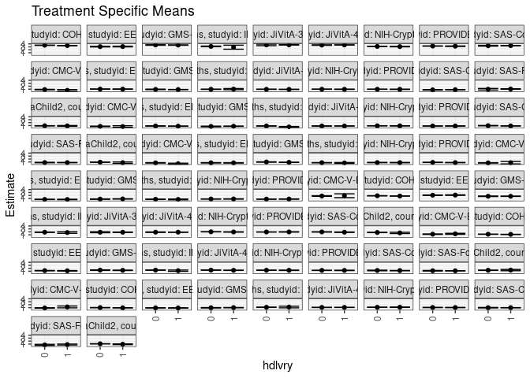

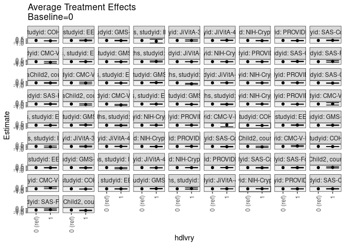

[figure not shown]

## Results Table

### Parameter: TSM

| agecat | studyid | country | intervention_level | baseline_level | estimate | ci_lower | ci_upper |
| --- | --- | --- | --- | --- | --- | --- | --- |
| 0-3 months | COHORTS | INDIA | 0 | NA | 3.5375453 | 3.5163001 | 3.5587906 |
| 0-3 months | COHORTS | INDIA | 1 | NA | 3.4183576 | 3.3907895 | 3.4459258 |
| 0-3 months | EE | PAKISTAN | 0 | NA | 3.0691449 | 2.9595304 | 3.1787595 |
| 0-3 months | EE | PAKISTAN | 1 | NA | 3.0957900 | 2.9745039 | 3.2170762 |
| 0-3 months | GMS-Nepal | NEPAL | 0 | NA | 3.6344300 | 3.5379753 | 3.7308847 |
| 0-3 months | GMS-Nepal | NEPAL | 1 | NA | 3.5978495 | 3.5362063 | 3.6594926 |
| 0-3 months | IRC | INDIA | 0 | NA | 3.1431413 | 3.0310208 | 3.2552617 |
| 0-3 months | IRC | INDIA | 1 | NA | 2.8796715 | 2.1905479 | 3.5687951 |
| 0-3 months | JiVitA-3 | BANGLADESH | 0 | NA | 3.6707072 | 3.4087915 | 3.9326229 |
| 0-3 months | JiVitA-3 | BANGLADESH | 1 | NA | 3.6745784 | 3.6117203 | 3.7374364 |
| 0-3 months | JiVitA-4 | BANGLADESH | 0 | NA | 3.5992715 | 3.5115552 | 3.6869879 |
| 0-3 months | JiVitA-4 | BANGLADESH | 1 | NA | 3.6471459 | 3.6138939 | 3.6803979 |
| 0-3 months | NIH-Crypto | BANGLADESH | 0 | NA | 3.1445291 | 3.1033243 | 3.1857339 |
| 0-3 months | NIH-Crypto | BANGLADESH | 1 | NA | 3.0769222 | 2.9998810 | 3.1539635 |
| 0-3 months | PROVIDE | BANGLADESH | 0 | NA | 3.2708738 | 3.2273829 | 3.3143646 |
| 0-3 months | PROVIDE | BANGLADESH | 1 | NA | 3.2187543 | 3.1490776 | 3.2884309 |
| 0-3 months | SAS-CompFeed | INDIA | 0 | NA | 3.3768574 | 3.2453938 | 3.5083210 |
| 0-3 months | SAS-CompFeed | INDIA | 1 | NA | 3.4062582 | 3.3711212 | 3.4413952 |
| 3-6 months | CMC-V-BCS-2002 | INDIA | 0 | NA | 1.8068881 | 1.7044670 | 1.9093092 |
| 3-6 months | CMC-V-BCS-2002 | INDIA | 1 | NA | 1.9008428 | 1.2479048 | 2.5537808 |
| 3-6 months | COHORTS | INDIA | 0 | NA | 1.8886546 | 1.8701215 | 1.9071878 |
| 3-6 months | COHORTS | INDIA | 1 | NA | 1.8069033 | 1.7842125 | 1.8295941 |
| 3-6 months | EE | PAKISTAN | 0 | NA | 2.0861544 | 2.0134940 | 2.1588147 |
| 3-6 months | EE | PAKISTAN | 1 | NA | 2.1173492 | 2.0196594 | 2.2150389 |
| 3-6 months | GMS-Nepal | NEPAL | 0 | NA | 1.7176189 | 1.6336575 | 1.8015804 |
| 3-6 months | GMS-Nepal | NEPAL | 1 | NA | 1.7162616 | 1.6690774 | 1.7634458 |
| 3-6 months | IRC | INDIA | 0 | NA | 1.8829475 | 1.8178679 | 1.9480270 |
| 3-6 months | IRC | INDIA | 1 | NA | 1.7701196 | 1.5123539 | 2.0278853 |
| 3-6 months | JiVitA-3 | BANGLADESH | 0 | NA | 1.8767695 | 1.7171555 | 2.0363836 |
| 3-6 months | JiVitA-3 | BANGLADESH | 1 | NA | 1.8745764 | 1.8125792 | 1.9365736 |

[output cut: 118 more lines]

### Parameter: E(Y)

| agecat | studyid | country | intervention_level | baseline_level | estimate | ci_lower | ci_upper |
| --- | --- | --- | --- | --- | --- | --- | --- |
| 0-3 months | COHORTS | INDIA | NA | NA | 3.4928630 | 3.4759520 | 3.5097739 |
| 0-3 months | EE | PAKISTAN | NA | NA | 3.0782627 | 2.9950537 | 3.1614717 |
| 0-3 months | GMS-Nepal | NEPAL | NA | NA | 3.6065886 | 3.5542997 | 3.6588775 |
| 0-3 months | IRC | INDIA | NA | NA | 3.1382493 | 3.0275242 | 3.2489743 |
| 0-3 months | JiVitA-3 | BANGLADESH | NA | NA | 3.6741702 | 3.6068245 | 3.7415159 |
| 0-3 months | JiVitA-4 | BANGLADESH | NA | NA | 3.6373098 | 3.6059106 | 3.6687089 |
| 0-3 months | NIH-Crypto | BANGLADESH | NA | NA | 3.1292449 | 3.0928504 | 3.1656393 |
| 0-3 months | PROVIDE | BANGLADESH | NA | NA | 3.2576810 | 3.2206777 | 3.2946843 |
| 0-3 months | SAS-CompFeed | INDIA | NA | NA | 3.4022425 | 3.3615716 | 3.4429134 |
| 3-6 months | CMC-V-BCS-2002 | INDIA | NA | NA | 1.8090444 | 1.7078462 | 1.9102427 |
| 3-6 months | COHORTS | INDIA | NA | NA | 1.8571473 | 1.8427398 | 1.8715548 |
| 3-6 months | EE | PAKISTAN | NA | NA | 2.0964778 | 2.0380696 | 2.1548860 |
| 3-6 months | GMS-Nepal | NEPAL | NA | NA | 1.7165753 | 1.6754325 | 1.7577181 |
| 3-6 months | IRC | INDIA | NA | NA | 1.8806738 | 1.8168757 | 1.9444719 |
| 3-6 months | JiVitA-3 | BANGLADESH | NA | NA | 1.8747997 | 1.8153916 | 1.9342078 |
| 3-6 months | JiVitA-4 | BANGLADESH | NA | NA | 1.8985588 | 1.8677350 | 1.9293826 |
| 3-6 months | NIH-Crypto | BANGLADESH | NA | NA | 2.0057973 | 1.9693775 | 2.0422170 |
| 3-6 months | PROVIDE | BANGLADESH | NA | NA | 1.9657457 | 1.9318660 | 1.9996254 |
| 3-6 months | SAS-CompFeed | INDIA | NA | NA | 1.9057893 | 1.8442152 | 1.9673633 |
| 3-6 months | TanzaniaChild2 | TANZANIA, UNITED REPUBLIC OF | NA | NA | 1.7898054 | 1.7530632 | 1.8265475 |
| 6-9 months | CMC-V-BCS-2002 | INDIA | NA | NA | 1.2178990 | 1.1397587 | 1.2960393 |
| 6-9 months | COHORTS | INDIA | NA | NA | 1.1799194 | 1.1665767 | 1.1932622 |
| 6-9 months | EE | PAKISTAN | NA | NA | 1.1782840 | 1.1310763 | 1.2254917 |
| 6-9 months | GMS-Nepal | NEPAL | NA | NA | 1.3143024 | 1.2716844 | 1.3569203 |
| 6-9 months | IRC | INDIA | NA | NA | 1.3724009 | 1.3237927 | 1.4210091 |
| 6-9 months | JiVitA-4 | BANGLADESH | NA | NA | 1.3272128 | 1.3055780 | 1.3488477 |
| 6-9 months | NIH-Crypto | BANGLADESH | NA | NA | 1.3282695 | 1.2988292 | 1.3577098 |
| 6-9 months | PROVIDE | BANGLADESH | NA | NA | 1.2824185 | 1.2571827 | 1.3076542 |
| 6-9 months | SAS-CompFeed | INDIA | NA | NA | 1.2213254 | 1.1902976 | 1.2523532 |
| 6-9 months | SAS-FoodSuppl | INDIA | NA | NA | 1.1426155 | 1.1021386 | 1.1830923 |
| 6-9 months | TanzaniaChild2 | TANZANIA, UNITED REPUBLIC OF | NA | NA | 1.3208993 | 1.2838000 | 1.3579985 |
| 9-12 months | CMC-V-BCS-2002 | INDIA | NA | NA | 0.9006772 | 0.8324254 | 0.9689289 |
| 9-12 months | COHORTS | INDIA | NA | NA | 0.9865891 | 0.9721570 | 1.0010213 |
| 9-12 months | EE | PAKISTAN | NA | NA | 0.9171111 | 0.8817992 | 0.9524229 |
| 9-12 months | GMS-Nepal | NEPAL | NA | NA | 1.0006065 | 0.9668961 | 1.0343169 |
| 9-12 months | IRC | INDIA | NA | NA | 1.1234734 | 1.0841051 | 1.1628417 |
| 9-12 months | JiVitA-4 | BANGLADESH | NA | NA | 1.0744194 | 1.0555407 | 1.0932981 |
| 9-12 months | NIH-Crypto | BANGLADESH | NA | NA | 1.1234745 | 1.0972274 | 1.1497215 |
| 9-12 months | PROVIDE | BANGLADESH | NA | NA | 1.0499750 | 1.0230130 | 1.0769370 |
| 9-12 months | SAS-CompFeed | INDIA | NA | NA | 0.9865891 | 0.9598365 | 1.0133416 |
| 9-12 months | SAS-FoodSuppl | INDIA | NA | NA | 0.8106649 | 0.6745544 | 0.9467754 |
| 9-12 months | TanzaniaChild2 | TANZANIA, UNITED REPUBLIC OF | NA | NA | 1.0841292 | 1.0490852 | 1.1191732 |
| 12-15 months | CMC-V-BCS-2002 | INDIA | NA | NA | 0.8535918 | 0.7835242 | 0.9236593 |
| 12-15 months | EE | PAKISTAN | NA | NA | 1.0107552 | 0.9781087 | 1.0434018 |
| 12-15 months | GMS-Nepal | NEPAL | NA | NA | 0.8815392 | 0.8515745 | 0.9115039 |
| 12-15 months | IRC | INDIA | NA | NA | 0.9553539 | 0.9137750 | 0.9969329 |
| 12-15 months | JiVitA-4 | BANGLADESH | NA | NA | 0.9336283 | 0.9165436 | 0.9507131 |
| 12-15 months | NIH-Crypto | BANGLADESH | NA | NA | 0.9711395 | 0.9465805 | 0.9956985 |
| 12-15 months | PROVIDE | BANGLADESH | NA | NA | 0.9597501 | 0.9335899 | 0.9859102 |
| 12-15 months | SAS-CompFeed | INDIA | NA | NA | 0.8161882 | 0.7765985 | 0.8557780 |
| 12-15 months | SAS-FoodSuppl | INDIA | NA | NA | 1.0267825 | 0.9374856 | 1.1160794 |
| 12-15 months | TanzaniaChild2 | TANZANIA, UNITED REPUBLIC OF | NA | NA | 0.9274012 | 0.8891908 | 0.9656115 |
| 15-18 months | CMC-V-BCS-2002 | INDIA | NA | NA | 0.7337508 | 0.6705522 | 0.7969495 |
| 15-18 months | EE | PAKISTAN | NA | NA | 0.8381895 | 0.8057813 | 0.8705977 |
| 15-18 months | GMS-Nepal | NEPAL | NA | NA | 0.7536062 | 0.7171842 | 0.7900282 |
| 15-18 months | IRC | INDIA | NA | NA | 0.8591216 | 0.8197594 | 0.8984837 |
| 15-18 months | JiVitA-4 | BANGLADESH | NA | NA | 0.8551359 | 0.8372482 | 0.8730235 |
| 15-18 months | NIH-Crypto | BANGLADESH | NA | NA | 0.9177168 | 0.8947657 | 0.9406678 |
| 15-18 months | PROVIDE | BANGLADESH | NA | NA | 0.8560998 | 0.8320145 | 0.8801852 |
| 15-18 months | SAS-CompFeed | INDIA | NA | NA | 0.8886052 | 0.8682282 | 0.9089822 |
| 15-18 months | SAS-FoodSuppl | INDIA | NA | NA | 0.7947861 | 0.7590601 | 0.8305122 |
| 15-18 months | TanzaniaChild2 | TANZANIA, UNITED REPUBLIC OF | NA | NA | 0.9282684 | 0.8848562 | 0.9716806 |
| 18-21 months | CMC-V-BCS-2002 | INDIA | NA | NA | 0.6998980 | 0.6359097 | 0.7638864 |
| 18-21 months | EE | PAKISTAN | NA | NA | 0.7189044 | 0.6845146 | 0.7532942 |
| 18-21 months | GMS-Nepal | NEPAL | NA | NA | 0.9054330 | 0.8696956 | 0.9411703 |
| 18-21 months | IRC | INDIA | NA | NA | 0.7598022 | 0.7214752 | 0.7981291 |
| 18-21 months | NIH-Crypto | BANGLADESH | NA | NA | 0.7977755 | 0.7744353 | 0.8211158 |
| 18-21 months | PROVIDE | BANGLADESH | NA | NA | 0.8393377 | 0.8153485 | 0.8633269 |
| 21-24 months | CMC-V-BCS-2002 | INDIA | NA | NA | 0.7007026 | 0.6410363 | 0.7603689 |
| 21-24 months | EE | PAKISTAN | NA | NA | 0.6493410 | 0.6112910 | 0.6873909 |
| 21-24 months | GMS-Nepal | NEPAL | NA | NA | 0.8018481 | 0.7541733 | 0.8495230 |
| 21-24 months | IRC | INDIA | NA | NA | 0.7084129 | 0.6674749 | 0.7493508 |
| 21-24 months | NIH-Crypto | BANGLADESH | NA | NA | 0.7993353 | 0.7748026 | 0.8238681 |
| 21-24 months | PROVIDE | BANGLADESH | NA | NA | 0.7631391 | 0.7377453 | 0.7885328 |

### Parameter: ATE

| agecat | studyid | country | intervention_level | baseline_level | estimate | ci_lower | ci_upper |
| --- | --- | --- | --- | --- | --- | --- | --- |
| 0-3 months | COHORTS | INDIA | 0 | 0 | 0.0000000 | 0.0000000 | 0.0000000 |
| 0-3 months | COHORTS | INDIA | 1 | 0 | -0.1191877 | -0.1539924 | -0.0843830 |
| 0-3 months | EE | PAKISTAN | 0 | 0 | 0.0000000 | 0.0000000 | 0.0000000 |
| 0-3 months | EE | PAKISTAN | 1 | 0 | 0.0266451 | -0.1368348 | 0.1901250 |
| 0-3 months | GMS-Nepal | NEPAL | 0 | 0 | 0.0000000 | 0.0000000 | 0.0000000 |
| 0-3 months | GMS-Nepal | NEPAL | 1 | 0 | -0.0365805 | -0.1510506 | 0.0778895 |
| 0-3 months | IRC | INDIA | 0 | 0 | 0.0000000 | 0.0000000 | 0.0000000 |
| 0-3 months | IRC | INDIA | 1 | 0 | -0.2634698 | -0.9616548 | 0.4347152 |
| 0-3 months | JiVitA-3 | BANGLADESH | 0 | 0 | 0.0000000 | 0.0000000 | 0.0000000 |
| 0-3 months | JiVitA-3 | BANGLADESH | 1 | 0 | 0.0038711 | -0.2532315 | 0.2609738 |
| 0-3 months | JiVitA-4 | BANGLADESH | 0 | 0 | 0.0000000 | 0.0000000 | 0.0000000 |
| 0-3 months | JiVitA-4 | BANGLADESH | 1 | 0 | 0.0478743 | -0.0470926 | 0.1428413 |
| 0-3 months | NIH-Crypto | BANGLADESH | 0 | 0 | 0.0000000 | 0.0000000 | 0.0000000 |
| 0-3 months | NIH-Crypto | BANGLADESH | 1 | 0 | -0.0676068 | -0.1549749 | 0.0197613 |
| 0-3 months | PROVIDE | BANGLADESH | 0 | 0 | 0.0000000 | 0.0000000 | 0.0000000 |
| 0-3 months | PROVIDE | BANGLADESH | 1 | 0 | -0.0521195 | -0.1342553 | 0.0300163 |
| 0-3 months | SAS-CompFeed | INDIA | 0 | 0 | 0.0000000 | 0.0000000 | 0.0000000 |
| 0-3 months | SAS-CompFeed | INDIA | 1 | 0 | 0.0294009 | -0.0910020 | 0.1498037 |
| 3-6 months | CMC-V-BCS-2002 | INDIA | 0 | 0 | 0.0000000 | 0.0000000 | 0.0000000 |
| 3-6 months | CMC-V-BCS-2002 | INDIA | 1 | 0 | 0.0939547 | -0.5669675 | 0.7548769 |
| 3-6 months | COHORTS | INDIA | 0 | 0 | 0.0000000 | 0.0000000 | 0.0000000 |
| 3-6 months | COHORTS | INDIA | 1 | 0 | -0.0817513 | -0.1110490 | -0.0524537 |
| 3-6 months | EE | PAKISTAN | 0 | 0 | 0.0000000 | 0.0000000 | 0.0000000 |
| 3-6 months | EE | PAKISTAN | 1 | 0 | 0.0311948 | -0.0905542 | 0.1529438 |
| 3-6 months | GMS-Nepal | NEPAL | 0 | 0 | 0.0000000 | 0.0000000 | 0.0000000 |
| 3-6 months | GMS-Nepal | NEPAL | 1 | 0 | -0.0013573 | -0.0976687 | 0.0949540 |
| 3-6 months | IRC | INDIA | 0 | 0 | 0.0000000 | 0.0000000 | 0.0000000 |
| 3-6 months | IRC | INDIA | 1 | 0 | -0.1128279 | -0.3786822 | 0.1530264 |
| 3-6 months | JiVitA-3 | BANGLADESH | 0 | 0 | 0.0000000 | 0.0000000 | 0.0000000 |
| 3-6 months | JiVitA-3 | BANGLADESH | 1 | 0 | -0.0021931 | -0.1681489 | 0.1637626 |

[output cut: 118 more lines]

### Parameter: PAR

| agecat | studyid | country | intervention_level | baseline_level | estimate | ci_lower | ci_upper |
| --- | --- | --- | --- | --- | --- | --- | --- |
| 0-3 months | COHORTS | INDIA | 0 | NA | -0.0446824 | -0.0578369 | -0.0315278 |
| 0-3 months | EE | PAKISTAN | 0 | NA | 0.0091178 | -0.0468422 | 0.0650777 |
| 0-3 months | GMS-Nepal | NEPAL | 0 | NA | -0.0278414 | -0.1149759 | 0.0592930 |
| 0-3 months | IRC | INDIA | 0 | NA | -0.0048920 | -0.0227130 | 0.0129290 |
| 0-3 months | JiVitA-3 | BANGLADESH | 0 | NA | 0.0034630 | -0.2265135 | 0.2334395 |
| 0-3 months | JiVitA-4 | BANGLADESH | 0 | NA | 0.0380382 | -0.0374480 | 0.1135245 |
| 0-3 months | NIH-Crypto | BANGLADESH | 0 | NA | -0.0152842 | -0.0351437 | 0.0045752 |
| 0-3 months | PROVIDE | BANGLADESH | 0 | NA | -0.0131928 | -0.0340575 | 0.0076720 |
| 0-3 months | SAS-CompFeed | INDIA | 0 | NA | 0.0253851 | -0.0808382 | 0.1316085 |
| 3-6 months | CMC-V-BCS-2002 | INDIA | 0 | NA | 0.0021563 | -0.0144422 | 0.0187549 |
| 3-6 months | COHORTS | INDIA | 0 | NA | -0.0315074 | -0.0428588 | -0.0201560 |
| 3-6 months | EE | PAKISTAN | 0 | NA | 0.0103235 | -0.0300046 | 0.0506516 |
| 3-6 months | GMS-Nepal | NEPAL | 0 | NA | -0.0010436 | -0.0750954 | 0.0730081 |
| 3-6 months | IRC | INDIA | 0 | NA | -0.0022736 | -0.0091009 | 0.0045537 |
| 3-6 months | JiVitA-3 | BANGLADESH | 0 | NA | -0.0019698 | -0.1510452 | 0.1471056 |
| 3-6 months | JiVitA-4 | BANGLADESH | 0 | NA | 0.0002079 | -0.0603028 | 0.0607186 |
| 3-6 months | NIH-Crypto | BANGLADESH | 0 | NA | -0.0117587 | -0.0303970 | 0.0068797 |
| 3-6 months | PROVIDE | BANGLADESH | 0 | NA | 0.0044866 | -0.0150605 | 0.0240337 |
| 3-6 months | SAS-CompFeed | INDIA | 0 | NA | -0.0728884 | -0.1714969 | 0.0257200 |
| 3-6 months | TanzaniaChild2 | TANZANIA, UNITED REPUBLIC OF | 0 | NA | -0.0025337 | -0.0078549 | 0.0027874 |
| 6-9 months | CMC-V-BCS-2002 | INDIA | 0 | NA | 0.0026812 | -0.0024990 | 0.0078613 |
| 6-9 months | COHORTS | INDIA | 0 | NA | -0.0188183 | -0.0294092 | -0.0082273 |
| 6-9 months | EE | PAKISTAN | 0 | NA | -0.0177844 | -0.0502852 | 0.0147165 |
| 6-9 months | GMS-Nepal | NEPAL | 0 | NA | -0.0545308 | -0.1318856 | 0.0228240 |
| 6-9 months | IRC | INDIA | 0 | NA | -0.0038102 | -0.0100580 | 0.0024377 |
| 6-9 months | JiVitA-4 | BANGLADESH | 0 | NA | -0.0500623 | -0.0866852 | -0.0134395 |
| 6-9 months | NIH-Crypto | BANGLADESH | 0 | NA | -0.0046779 | -0.0191775 | 0.0098218 |
| 6-9 months | PROVIDE | BANGLADESH | 0 | NA | -0.0020753 | -0.0170985 | 0.0129480 |
| 6-9 months | SAS-CompFeed | INDIA | 0 | NA | -0.0408842 | -0.1419771 | 0.0602088 |
| 6-9 months | SAS-FoodSuppl | INDIA | 0 | NA | -0.0133386 | -0.0954441 | 0.0687669 |
| 6-9 months | TanzaniaChild2 | TANZANIA, UNITED REPUBLIC OF | 0 | NA | 0.0010044 | -0.0042944 | 0.0063033 |
| 9-12 months | CMC-V-BCS-2002 | INDIA | 0 | NA | 0.0088776 | -0.0011590 | 0.0189143 |
| 9-12 months | COHORTS | INDIA | 0 | NA | -0.0257070 | -0.0370334 | -0.0143806 |
| 9-12 months | EE | PAKISTAN | 0 | NA | -0.0093276 | -0.0330513 | 0.0143962 |
| 9-12 months | GMS-Nepal | NEPAL | 0 | NA | 0.0397930 | -0.0281507 | 0.1077367 |
| 9-12 months | IRC | INDIA | 0 | NA | 0.0014942 | -0.0052978 | 0.0082862 |
| 9-12 months | JiVitA-4 | BANGLADESH | 0 | NA | -0.0029556 | -0.0345382 | 0.0286270 |
| 9-12 months | NIH-Crypto | BANGLADESH | 0 | NA | 0.0025183 | -0.0113048 | 0.0163414 |
| 9-12 months | PROVIDE | BANGLADESH | 0 | NA | -0.0040074 | -0.0197996 | 0.0117849 |
| 9-12 months | SAS-CompFeed | INDIA | 0 | NA | 0.0028348 | -0.0802406 | 0.0859102 |
| 9-12 months | SAS-FoodSuppl | INDIA | 0 | NA | 0.0951019 | -0.1098189 | 0.3000227 |
| 9-12 months | TanzaniaChild2 | TANZANIA, UNITED REPUBLIC OF | 0 | NA | -0.0016460 | -0.0051019 | 0.0018099 |
| 12-15 months | CMC-V-BCS-2002 | INDIA | 0 | NA | -0.0065236 | -0.0148584 | 0.0018111 |
| 12-15 months | EE | PAKISTAN | 0 | NA | -0.0036625 | -0.0266517 | 0.0193266 |
| 12-15 months | GMS-Nepal | NEPAL | 0 | NA | -0.0364753 | -0.1026257 | 0.0296750 |
| 12-15 months | IRC | INDIA | 0 | NA | 0.0009747 | -0.0038981 | 0.0058475 |
| 12-15 months | JiVitA-4 | BANGLADESH | 0 | NA | -0.0169991 | -0.0459352 | 0.0119369 |
| 12-15 months | NIH-Crypto | BANGLADESH | 0 | NA | -0.0053089 | -0.0178908 | 0.0072730 |
| 12-15 months | PROVIDE | BANGLADESH | 0 | NA | -0.0048131 | -0.0195690 | 0.0099428 |
| 12-15 months | SAS-CompFeed | INDIA | 0 | NA | 0.0507062 | -0.0278785 | 0.1292910 |
| 12-15 months | SAS-FoodSuppl | INDIA | 0 | NA | 0.0575087 | -0.1641453 | 0.2791628 |
| 12-15 months | TanzaniaChild2 | TANZANIA, UNITED REPUBLIC OF | 0 | NA | -0.0003004 | -0.0034443 | 0.0028435 |
| 15-18 months | CMC-V-BCS-2002 | INDIA | 0 | NA | -0.0016292 | -0.0086946 | 0.0054362 |
| 15-18 months | EE | PAKISTAN | 0 | NA | -0.0225305 | -0.0457161 | 0.0006550 |
| 15-18 months | GMS-Nepal | NEPAL | 0 | NA | 0.0467963 | -0.0283963 | 0.1219890 |
| 15-18 months | IRC | INDIA | 0 | NA | -0.0062626 | -0.0124719 | -0.0000533 |
| 15-18 months | JiVitA-4 | BANGLADESH | 0 | NA | 0.0036967 | -0.0259521 | 0.0333455 |
| 15-18 months | NIH-Crypto | BANGLADESH | 0 | NA | -0.0047792 | -0.0173072 | 0.0077488 |
| 15-18 months | PROVIDE | BANGLADESH | 0 | NA | 0.0009001 | -0.0136695 | 0.0154697 |
| 15-18 months | SAS-CompFeed | INDIA | 0 | NA | -0.0772276 | -0.1489811 | -0.0054741 |
| 15-18 months | SAS-FoodSuppl | INDIA | 0 | NA | -0.0095914 | -0.0805583 | 0.0613755 |
| 15-18 months | TanzaniaChild2 | TANZANIA, UNITED REPUBLIC OF | 0 | NA | -0.0018143 | -0.0082053 | 0.0045766 |
| 18-21 months | CMC-V-BCS-2002 | INDIA | 0 | NA | -0.0078705 | -0.0152849 | -0.0004560 |
| 18-21 months | EE | PAKISTAN | 0 | NA | -0.0075488 | -0.0292226 | 0.0141250 |
| 18-21 months | GMS-Nepal | NEPAL | 0 | NA | -0.0884709 | -0.1525161 | -0.0244257 |
| 18-21 months | IRC | INDIA | 0 | NA | -0.0017533 | -0.0056992 | 0.0021925 |
| 18-21 months | NIH-Crypto | BANGLADESH | 0 | NA | -0.0040902 | -0.0166966 | 0.0085162 |
| 18-21 months | PROVIDE | BANGLADESH | 0 | NA | -0.0166942 | -0.0308619 | -0.0025266 |
| 21-24 months | CMC-V-BCS-2002 | INDIA | 0 | NA | 0.0012844 | -0.0092763 | 0.0118451 |
| 21-24 months | EE | PAKISTAN | 0 | NA | -0.0092516 | -0.0336501 | 0.0151469 |
| 21-24 months | GMS-Nepal | NEPAL | 0 | NA | 0.0505241 | -0.0169462 | 0.1179943 |
| 21-24 months | IRC | INDIA | 0 | NA | -0.0010192 | -0.0048373 | 0.0027990 |
| 21-24 months | NIH-Crypto | BANGLADESH | 0 | NA | 0.0022385 | -0.0111829 | 0.0156598 |
| 21-24 months | PROVIDE | BANGLADESH | 0 | NA | 0.0047876 | -0.0102267 | 0.0198018 |